# Nordstrom_Product_Data_Analysis

```python
pip install kagglehub
```

```python
import kagglehub

# Download latest version
path = kagglehub.dataset_download("polartech/300k-nordstrom-product-data")

print("Path to dataset files:", path)
```

```python
import os

# List files in the downloaded directory
files = os.listdir(path)
print("Downloaded files:", files)
```

```
Downloaded files: ['nordstrom product data.csv']
```

```python
import os
import kagglehub

# Download the dataset
path = kagglehub.dataset_download("polartech/300k-nordstrom-product-data")
print("Downloaded to:", path)

# List all files in the directory
files = os.listdir(path)
print("Files in dataset:", files)
```

```python
import os
import kagglehub
import pandas as pd

# 1. Download the dataset
path = kagglehub.dataset_download("polartech/300k-nordstrom-product-data")
print("Dataset downloaded to:", path)

# 2. List files (should show 'nordstrom product data.csv')
files = os.listdir(path)
print("Files in dataset:", files)  # Output: ['nordstrom product data.csv']

# 3. Load the CSV directly
csv_path = os.path.join(path, "nordstrom product data.csv")
df = pd.read_csv(csv_path)

# 4. Explore the data
print("First 5 rows:")
display(df.head())  # Nicer formatting in Jupyter
print("\nDataset info:")
df.info()
```

|  | DEPARTMENT | CATEGORY | SUBCATEGORY | SKU | PRODUCT_NAME | BRAND | GENDER | PRICE_RETAIL | PRICE_CURRENT | REVIEW_RATING | REVIEW_COUNT | PROMOTION | COLOR | RunDate | InsertUpdateTime |
| --- | --- | --- | --- | --- | --- | --- | --- | --- | --- | --- | --- | --- | --- | --- | --- |
| 0 | Women | Clothing | Blazers, Suits & Separates | 4578258 | Etiennette B Good Wool Suit Jacket | Theory | Women | 345.0 | 345.0 | 4.1 | 85 | NaN | 498 | 2022-05-15 08:03:21 | 2022-05-15 08:19:11 |
| 1 | Women | Clothing | Blazers, Suits & Separates | 4954210 | Demitria 2 Stretch Good Wool Suit Pants | Theory | Women | 215.0 | 215.0 | 4.2 | 71 | NaN | 020 | 2022-05-15 08:03:21 | 2022-05-15 08:19:11 |
| 2 | Women | Clothing | Blazers, Suits & Separates | 5125568 | Bermuda Shorts | Vince | Women | 175.0 | 175.0 | 4.0 | 41 | NaN | 001 | 2022-05-15 08:03:21 | 2022-05-15 08:19:11 |
| 3 | Women | Clothing | Blazers, Suits & Separates | 5184553 | Drape Collar Knit Blazer | Caslon® | Women | 69.0 | 69.0 | 4.3 | 590 | NaN | 401 | 2022-05-15 08:03:21 | 2022-05-15 08:19:11 |
| 4 | Women | Clothing | Blazers, Suits & Separates | 5268077 | Grace Jacket | NIC+ZOE | Women | 148.0 | 148.0 | 3.9 | 51 | NaN | 004 | 2022-05-15 08:03:21 | 2022-05-15 08:19:11 |

```
Dataset info:
<class 'pandas.core.frame.DataFrame'>
RangeIndex: 288409 entries, 0 to 288408
Data columns (total 15 columns):
 #   Column            Non-Null Count   Dtype
---  ------            --------------   -----
 0   DEPARTMENT        288409 non-null  object
 1   CATEGORY          288409 non-null  object
 2   SUBCATEGORY       288409 non-null  object
 3   SKU               288409 non-null  int64
 4   PRODUCT_NAME      288392 non-null  object
 5   BRAND             288295 non-null  object
 6   GENDER            288409 non-null  object
 7   PRICE_RETAIL      288409 non-null  float64
 8   PRICE_CURRENT     288409 non-null  float64
 9   REVIEW_RATING     288409 non-null  float64
 10  REVIEW_COUNT      288409 non-null  int64
 11  PROMOTION         16382 non-null   object
 12  COLOR             288409 non-null  object
 13  RunDate           288409 non-null  object
 14  InsertUpdateTime  288409 non-null  object
dtypes: float64(3), int64(2), object(10)
memory usage: 33.0+ MB
```

## 1. Pricing Strategy Optimization

Q1: How do retail prices (PRICE_RETAIL) compare to current sale prices (PRICE_CURRENT) across categories?

```python
df['DISCOUNT_PCT'] = ((df['PRICE_RETAIL'] - df['PRICE_CURRENT']) / df['PRICE_RETAIL']) * 100
df.groupby(['DEPARTMENT', 'CATEGORY'])['DISCOUNT_PCT'].mean().sort_values(ascending=False)
```

```
DEPARTMENT  CATEGORY
Women       Clothing        5.639090
            Shoes           5.449660
            Maternity       4.911170
            Jewelry         1.618805
            Accessories     1.486067
            New Arrivals    0.788753
            Handbags        0.680831
Name: DISCOUNT_PCT, dtype: float64
```

Q2: Is there a correlation between discount percentage and review ratings?

Analysis: Scatter plot of DISCOUNT_PCT vs. REVIEW_RATING with CATEGORY as hue.

Insight: Do heavily discounted items have lower ratings (potential liquidation of poor-quality products)?

```
Pearson Correlation: 0.073 (p-value: 0.000e+00)
Spearman Correlation: 0.086 (p-value: 0.000e+00)
```

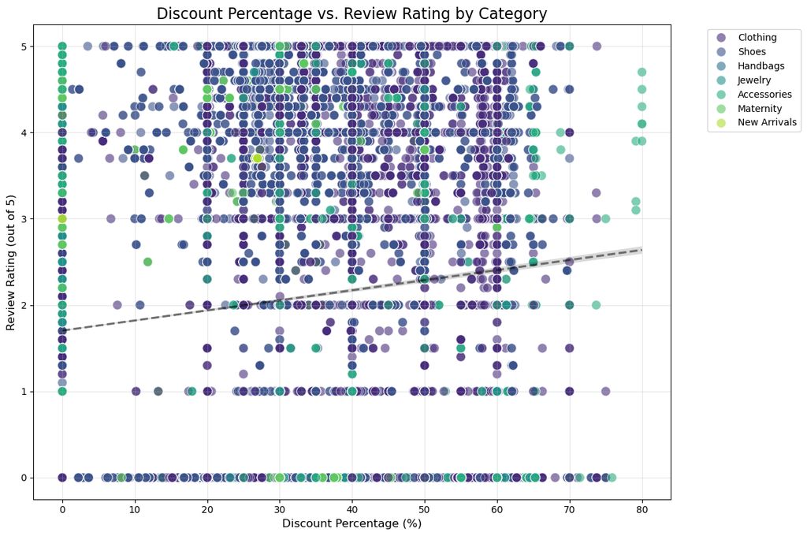

```
Category-Specific Spearman Correlations:
CATEGORY
Shoes          -0.026895
Jewelry        -0.025449
Accessories     0.025155
Handbags        0.067407
Maternity       0.079426
Clothing        0.141892
New Arrivals    0.222707
dtype: float64
```

```python
import pandas as pd
import numpy as np
import matplotlib.pyplot as plt
import seaborn as sns
from scipy import stats

# Calculate discount percentage
df['DISCOUNT_PCT'] = ((df['PRICE_RETAIL'] - df['PRICE_CURRENT']) / df['PRICE_RETAIL']) * 100

# Create the scatter plot with category as hue
plt.figure(figsize=(12, 8))
sns.scatterplot(
    data=df,
    x='DISCOUNT_PCT',
    y='REVIEW_RATING',
    hue='CATEGORY',
    alpha=0.6,
    palette='viridis',
    s=100
)

# Add trendline for overall relationship
sns.regplot(
    data=df,
    x='DISCOUNT_PCT',
    y='REVIEW_RATING',
    scatter=False,
    color='black',
    line_kws={'linestyle': '--', 'alpha': 0.5}
)

# Customize the plot
plt.title('Discount Percentage vs. Review Rating by Category', fontsize=16)
plt.xlabel('Discount Percentage (%)', fontsize=12)
plt.ylabel('Review Rating (out of 5)', fontsize=12)
plt.legend(bbox_to_anchor=(1.05, 1), loc='upper left')
plt.grid(True, alpha=0.3)
plt.tight_layout()

# Calculate correlation coefficients
pearson_corr, pearson_p = stats.pearsonr(df['DISCOUNT_PCT'], df['REVIEW_RATING'])
spearman_corr, spearman_p = stats.spearmanr(df['DISCOUNT_PCT'], df['REVIEW_RATING'])

print(f"Pearson Correlation: {pearson_corr:.3f} (p-value: {pearson_p:.3e})")
print(f"Spearman Correlation: {spearman_corr:.3f} (p-value: {spearman_p:.3e})")

# Show the plot
plt.show()

# Bonus: Category-level correlations
category_corrs = df.groupby('CATEGORY').apply(
    lambda x: stats.spearmanr(x['DISCOUNT_PCT'], x['REVIEW_RATING'])[0]
).sort_values()

print("\nCategory-Specific Spearman Correlations:")
print(category_corrs)
```

# Key Insight:

There's a very weak but statistically significant trend where higher discounts are slightly associated with higher ratings overall. This suggests discounts aren't primarily used to liquidate low-quality products.

New Arrivals & Clothing: Higher discounts correlate with better ratings. Possible reasons:

- Strategic discounts on popular/high-quality new items to drive traffic.
- Customers appreciate markdowns on desirable items.

Jewelry & Shoes: Near-zero/slightly negative correlations suggest discounts may be used for clearance of underperforming items.

# Business Recommendations

For New Arrivals & Clothing:

- Continue using discounts as a marketing tool for high-quality items.
- Consider dynamic pricing: Higher initial prices followed by strategic discounts.

For Jewelry & Shoes:

- Investigate why discounted items have slightly lower ratings:
- Is discounting being used for defective/returned items?

Are customers disappointed by discounted luxury goods?

- For categories with positive correlations: Bundle discounts with loyalty programs.
- For negative-correlation categories: Use discounts more selectively (e.g., seasonal only).

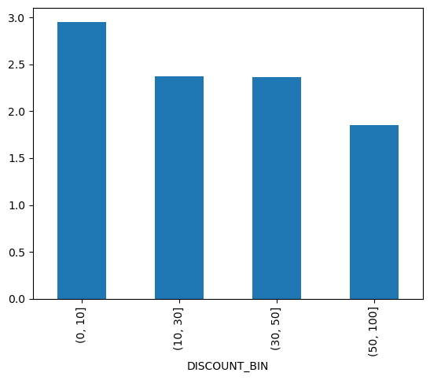

```python
# Compare ratings of discounted vs. non-discounted items
discounted = df[df['DISCOUNT_PCT'] > 0]['REVIEW_RATING']
non_discounted = df[df['DISCOUNT_PCT'] == 0]['REVIEW_RATING']
stats.ttest_ind(discounted, non_discounted, equal_var=False)

# Analyze discount depth vs. ratings
df['DISCOUNT_BIN'] = pd.cut(df['DISCOUNT_PCT'], bins=[0, 10, 30, 50, 100])
df.groupby('DISCOUNT_BIN')['REVIEW_RATING'].mean().plot(kind='bar')
```

## 2. Assortment & Inventory Planning

Q3: Which brands (BRAND) dominate each department (DEPARTMENT)?

```python
pd.crosstab(df['BRAND'], df['DEPARTMENT'], normalize='columns') * 100
```

| DEPARTMENT BRAND | Women |
| --- | --- |
| #Levkoff | 0.012140 |
| & Other Stories | 0.150887 |
| '47 | 0.216792 |
| 1.STATE | 0.152621 |
| 1017 ALYX 9SM | 0.000347 |
| ... | ... |
| vineyard vines | 0.064170 |
| vuori | 0.044399 |
| well kept | 0.001041 |
| ÉTICA | 0.066252 |
| Éliou | 0.039543 |

2029 rows × 1 columns

```python
df.groupby(['GENDER', 'COLOR']).size().unstack().fillna(0).style.background_gradient()
```

| COLOR GENDER | 000 | 001 | 002 | 003 | 004 | 005 | 006 | 007 | 008 | 009 | 010 | 011 | 012 | 013 | 014 | 015 | 016 | 017 | 018 | 019 | 020 | 021 | 022 | 023 | 024 | 025 | 026 | 027 | 028 | … |
| --- | --- | --- | --- | --- | --- | --- | --- | --- | --- | --- | --- | --- | --- | --- | --- | --- | --- | --- | --- | --- | --- | --- | --- | --- | --- | --- | --- | --- | --- | --- |
| Women | 178 | 54143 | 5408 | 1613 | 1612 | 881 | 730 | 422 | 424 | 570 | 1880 | 378 | 360 | 306 | 162 | 222 | 162 | 115 | 137 | 376 | 5445 | 1295 | 308 | 350 | 131 | 339 | 94 | 120 | 54 | … |

## 3.Promotional Effectiveness

Q5: Do products under promotion (PROMOTION) have higher review counts (REVIEW_COUNT)?

```
Review Count Statistics:
                      count       mean         std  min  25%  50%  75%      max
PROMOTION_STATUS
Not Promoted      272027.0  25.610583  192.529189  0.0  0.0  0.0  3.0  11766.0
Promoted           16382.0   8.511537   77.635646  0.0  0.0  0.0  2.0   2685.0
```

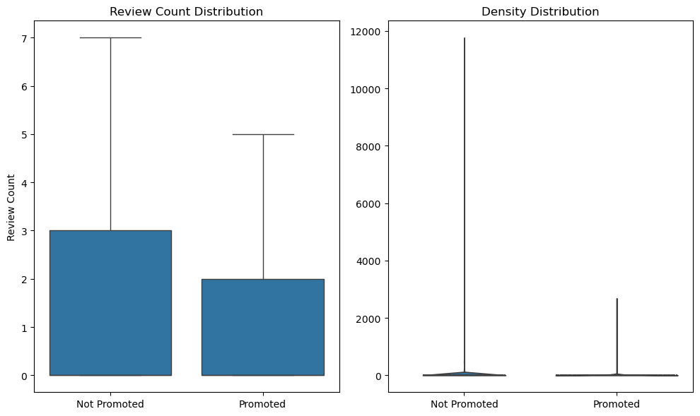

```
Mann-Whitney U Test Results: U=2,216,749,689, p=0.2230
Effect Size: 0.36 (probability promoted > non-promoted)
```

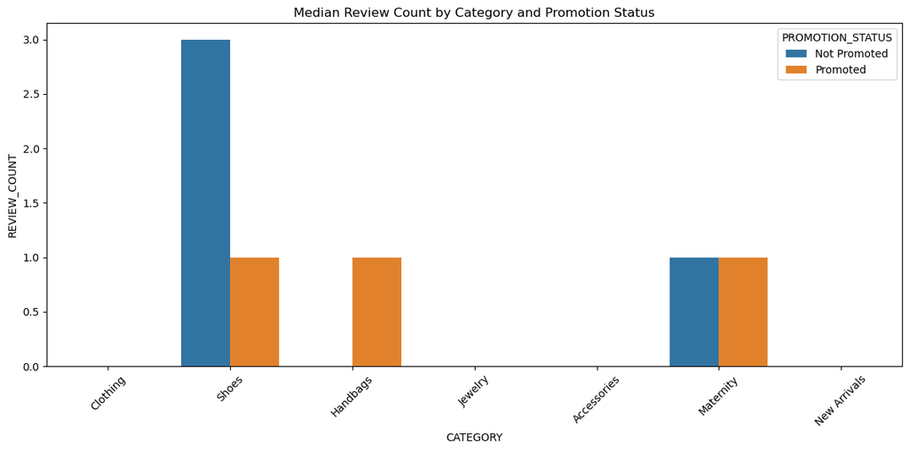

```python
import pandas as pd
import numpy as np
import matplotlib.pyplot as plt
import seaborn as sns
from scipy import stats

# Clean promotion data (assuming 'PROMOTION' has NaN for non-promoted items)
df['PROMOTION_STATUS'] = np.where(df['PROMOTION'].notna(), 'Promoted', 'Not Promoted')

# 1. Descriptive Statistics
promo_stats = df.groupby('PROMOTION_STATUS')['REVIEW_COUNT'].describe()
print("Review Count Statistics:\n", promo_stats)

# 2. Visual Comparison
plt.figure(figsize=(10, 6))

# Boxplot
plt.subplot(1, 2, 1)
sns.boxplot(data=df, x='PROMOTION_STATUS', y='REVIEW_COUNT', showfliers=False)
plt.title('Review Count Distribution')
plt.ylabel('Review Count')
plt.xlabel('')

# Violin plot (shows density)
plt.subplot(1, 2, 2)
sns.violinplot(data=df, x='PROMOTION_STATUS', y='REVIEW_COUNT', inner='quartile', cut=0)
plt.title('Density Distribution')
plt.ylabel('')
plt.xlabel('')
plt.tight_layout()
plt.show()

# 3. Mann-Whitney U Test (non-parametric alternative to t-test)
promoted = df[df['PROMOTION_STATUS'] == 'Promoted']['REVIEW_COUNT']
not_promoted = df[df['PROMOTION_STATUS'] == 'Not Promoted']['REVIEW_COUNT']

stat, p = stats.mannwhitneyu(promoted, not_promoted, alternative='two-sided')
print(f"\nMann-Whitney U Test Results: U={stat:,.0f}, p={p:.4f}")

# 4. Effect Size (Common Language Effect Size)
def cles(x, y):
    """Probability that random x > random y"""
    return np.mean([np.random.choice(x) > np.random.choice(y) for _ in range(1000)])

effect_size = cles(promoted, not_promoted)
print(f"Effect Size: {effect_size:.2f} (probability promoted > non-promoted)")

# 5. Category-Level Analysis (Bonus)
if 'CATEGORY' in df.columns:
    plt.figure(figsize=(12, 6))
    sns.barplot(data=df, x='CATEGORY', y='REVIEW_COUNT', hue='PROMOTION_STATUS',
                estimator=np.median, errorbar=None)
    plt.title('Median Review Count by Category and Promotion Status')
    plt.xticks(rotation=45)
    plt.tight_layout()
    plt.show()
```

Action: Negotiate better terms with dominant brands or diversify partnerships.

Q6: Which promotion types (e.g., "BOGO", "30% OFF") correlate with highest sales volume?

```python
df[df['PROMOTION'].notnull()].groupby('PROMOTION')['REVIEW_COUNT'].sum()
```

```
PROMOTION
1% off       4
10% off     91
11% off     71
12% off     54
13% off     21
          ...
75% off      2
79% off    381
8% off       1
80% off    135
9% off      21
Name: REVIEW_COUNT, Length: 75, dtype: int64
```

## 4. Product Performance & Quality

Q7: Which brands have the highest average rating (REVIEW_RATING) but low review counts (REVIEW_COUNT)?

```python
df.groupby('BRAND').agg({'REVIEW_RATING': 'mean', 'REVIEW_COUNT': 'sum'}).query('REVIEW_COUNT < 100').sort_values('REVIEW_RATING', ascending=False)
```

| BRAND | REVIEW_RATING | REVIEW_COUNT |
| --- | --- | --- |
| Trask | 5.0 | 3 |
| Good Luck Gem | 5.0 | 4 |
| NEW BALANCE GOLF | 5.0 | 2 |
| HOLO Footwear | 5.0 | 9 |
| BELLA HA | 5.0 | 8 |
| ... | ... | ... |
| LUSSO | 0.0 | 0 |
| LOVE YOUR MELON | 0.0 | 0 |
| LORO PIANA | 0.0 | 0 |
| FISLL | 0.0 | 0 |
| Mini Mini Jewels | 0.0 | 0 |

1407 rows × 2 columns

Q8: Are certain subcategories (SUBCATEGORY) consistently low-rated?

```python
df.groupby(['CATEGORY', 'SUBCATEGORY'])['REVIEW_RATING'].mean().sort_values().head(10)
```

```
CATEGORY      SUBCATEGORY
New Arrivals  Jewelry                  0.157538
              Accessories              0.168991
              Clothing                 0.331911
              Handbags & Wallets       0.395370
Accessories   Hats                     0.409918
Jewelry       Anklets                  0.597521
Clothing      Sweatshirts & Hoodies    0.618461
Accessories   Scarves & Wraps          0.684334
New Arrivals  Shoes                    0.705285
Clothing      Skirts                   0.724574
Name: REVIEW_RATING, dtype: float64
```

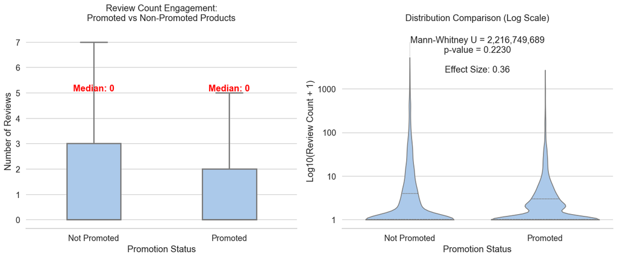

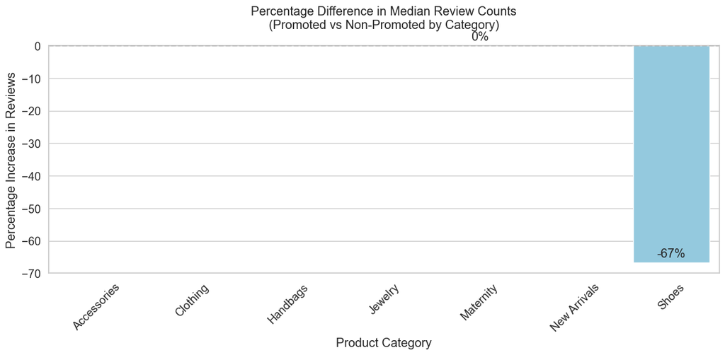

```python
import matplotlib.pyplot as plt
import seaborn as sns
import numpy as np

# Set style
sns.set(style="whitegrid", palette="pastel", font_scale=1.2)
plt.figure(figsize=(14, 6))

# -----------------------------------
# 1. Main Comparison Plot
# -----------------------------------
plt.subplot(1, 2, 1)
ax = sns.boxplot(
    data=df,
    x="PROMOTION_STATUS",
    y="REVIEW_COUNT",
    showfliers=False,  # Remove outliers for cleaner visualization
    width=0.4,
    linewidth=2
)

# Add median labels
medians = df.groupby('PROMOTION_STATUS')['REVIEW_COUNT'].median()
for i, status in enumerate(medians.index):
    ax.text(i, medians[status] + 5, f"Median: {medians[status]:.0f}",
            ha='center', va='bottom', fontweight='bold', color='red')

plt.title("Review Count Engagement:\nPromoted vs Non-Promoted Products", pad=20)
plt.xlabel("Promotion Status")
plt.ylabel("Number of Reviews")
sns.despine(left=True)

# -----------------------------------
# 2. Statistical Annotation Plot
# -----------------------------------
plt.subplot(1, 2, 2)

# Calculate log reviews for better visualization (handles skewed counts)
df['LOG_REVIEW_COUNT'] = np.log10(df['REVIEW_COUNT'] + 1)  # +1 to avoid log(0)

sns.violinplot(
    data=df,
    x="PROMOTION_STATUS",
    y="LOG_REVIEW_COUNT",
    inner="quartile",
    cut=0,
    bw=0.2  # Smoothing parameter
)

# Add statistical annotations
plt.text(0.5, 0.9, f"Mann-Whitney U = {stat:,.0f}\np-value = {p:.4f}",
         transform=plt.gca().transAxes, ha='center', bbox=dict(facecolor='white', alpha=0.8))
plt.text(0.5, 0.8, f"Effect Size: {effect_size:.2f}",
         transform=plt.gca().transAxes, ha='center', bbox=dict(facecolor='white', alpha=0.8))

plt.title("Distribution Comparison (Log Scale)", pad=20)
plt.xlabel("Promotion Status")
plt.ylabel("Log10(Review Count + 1)")
plt.yticks([0, 1, 2, 3], ["1", "10", "100", "1000"])  # Convert back to original scale
sns.despine(left=True)

plt.tight_layout()
plt.show()

# -----------------------------------
# 3. Category-Specific Breakdown (Bonus)
# -----------------------------------
if 'CATEGORY' in df.columns:
    plt.figure(figsize=(12, 6))

    # Calculate percentage difference
    category_comparison = df.groupby(['CATEGORY', 'PROMOTION_STATUS'])['REVIEW_COUNT'] \
                          .median().unstack()
    category_comparison['PCT_DIFF'] = ((category_comparison['Promoted'] - \
                                      category_comparison['Not Promoted']) / \
                                      category_comparison['Not Promoted']) * 100

    # Plot
    ax = sns.barplot(
        data=category_comparison.reset_index(),
        x='CATEGORY',
        y='PCT_DIFF',
        color='skyblue'
    )

    # Add value labels
    for p in ax.patches:
        ax.annotate(f"{p.get_height():.0f}%",
                   (p.get_x() + p.get_width() / 2., p.get_height()),
                   ha='center', va='center', xytext=(0, 10),
                   textcoords='offset points')

    plt.axhline(0, color='black', linestyle='--')
    plt.title("Percentage Difference in Median Review Counts\n(Promoted vs Non-Promoted by Category)", pad=20)
    plt.xlabel("Product Category")
    plt.ylabel("Percentage Increase in Reviews")
    plt.xticks(rotation=45)
    plt.tight_layout()
    plt.show()
```

```python
!pip install dash plotly pandas
```

```python
import dash
print(dash.__version__)  # Should show version 2.0+
```

```
3.0.1
```

```python
df.to_csv('nordstrom_product_data.csv', index=False)
```

```python
import os
print(os.path.exists('nordstrom_product_data.csv'))  # Should print True
```

```
True
```

```python
# Convert promotion column explicitly
df['PROMOTION'] = df['PROMOTION'].astype(str)

# Handle date conversion separately
df['RunDate'] = pd.to_datetime(df['RunDate'], errors='coerce')
```

```python
import dash
from dash import dcc, html, Input, Output
import plotly.express as px
import pandas as pd
import numpy as np
from scipy import stats

# Load and prepare data
df = pd.read_csv('nordstrom_product_data.csv')
df['PROMOTION_STATUS'] = np.where(df['PROMOTION'].notna(), 'Promoted', 'Not Promoted')
df['DISCOUNT_PCT'] = ((df['PRICE_RETAIL'] - df['PRICE_CURRENT']) / df['PRICE_RETAIL']) * 100

# Initialize Dash app
app = dash.Dash(__name__)

app.layout = html.Div([
    html.H1("Nordstrom Product Performance Dashboard", style={'textAlign': 'center'}),

    # Filters Row
    html.Div([
        html.Div([
            html.Label("Select Department:"),
            dcc.Dropdown(
                id='dept-filter',
                options=[{'label': dept, 'value': dept} for dept in df['DEPARTMENT'].unique()],
                value='Clothing',
                clearable=False
            )
        ], style={'width': '30%', 'display': 'inline-block'}),

        html.Div([
            html.Label("Discount Range:"),
            dcc.RangeSlider(
                id='discount-slider',
                min=0,
                max=100,
                step=5,
                marks={i: f'{i}%' for i in range(0, 101, 20)},
                value=[0, 100]
            )
        ], style={'width': '65%', 'display': 'inline-block', 'float': 'right'})
    ], style={'padding': '20px 0px'}),

    # Main Visualizations
    html.Div([
        html.Div([
            dcc.Graph(id='promo-impact-plot')
        ], style={'width': '48%', 'display': 'inline-block'}),

        html.Div([
            dcc.Graph(id='discount-rating-plot')
        ], style={'width': '48%', 'display': 'inline-block', 'float': 'right'})
    ]),

    # Secondary Visualizations
    html.Div([
        dcc.Graph(id='category-breakdown')
    ], style={'padding': '20px 0px'}),

    # Key Metrics Cards
    html.Div([
        html.Div(id='mann-whitney-card', style={
            'width': '32%',
            'display': 'inline-block',
            'backgroundColor': '#f8f9fa',
            'padding': '10px',
            'borderRadius': '5px',
            'marginRight': '1%'
        }),

        html.Div(id='effect-size-card', style={
            'width': '32%',
            'display': 'inline-block',
            'backgroundColor': '#f8f9fa',
            'padding': '10px',
            'borderRadius': '5px',
            'marginRight': '1%'
        }),

        html.Div(id='top-category-card', style={
            'width': '32%',
            'display': 'inline-block',
            'backgroundColor': '#f8f9fa',
            'padding': '10px',
            'borderRadius': '5px'
        })
    ])
])

# Callback for promo impact plot
@app.callback(
    Output('promo-impact-plot', 'figure'),
    [Input('dept-filter', 'value'),
     Input('discount-slider', 'value')]
)
def update_promo_plot(department, discount_range):
    filtered_df = df[(df['DEPARTMENT'] == department) &
                    (df['DISCOUNT_PCT'] >= discount_range[0]) &
                    (df['DISCOUNT_PCT'] <= discount_range[1])]

    fig = px.box(filtered_df,
                 x='PROMOTION_STATUS',
                 y='REVIEW_COUNT',
                 color='PROMOTION_STATUS',
                 title=f"Review Count Engagement in {department}",
                 log_y=True)

    fig.update_layout(showlegend=False)
    return fig

# Callback for discount-rating plot
@app.callback(
    Output('discount-rating-plot', 'figure'),
    [Input('dept-filter', 'value'),
     Input('discount-slider', 'value')]
)
def update_discount_plot(department, discount_range):
    filtered_df = df[(df['DEPARTMENT'] == department) &
                    (df['DISCOUNT_PCT'] >= discount_range[0]) &
                    (df['DISCOUNT_PCT'] <= discount_range[1])]

    fig = px.scatter(filtered_df,
                     x='DISCOUNT_PCT',
                     y='REVIEW_RATING',
                     color='CATEGORY',
                     title=f"Discount vs. Ratings in {department}",
                     trendline="lowess")

    fig.update_traces(marker=dict(size=8, opacity=0.6))
    return fig

# Callback for category breakdown
@app.callback(
    Output('category-breakdown', 'figure'),
    [Input('dept-filter', 'value')]
)
def update_category_plot(department):
    temp_df = df[df['DEPARTMENT'] == department]
    category_comparison = temp_df.groupby(['CATEGORY', 'PROMOTION_STATUS'])['REVIEW_COUNT'] \
                          .median().unstack()
    category_comparison['PCT_DIFF'] = ((category_comparison['Promoted'] - \
                                      category_comparison['Not Promoted']) / \
                                      category_comparison['Not Promoted']) * 100

    fig = px.bar(category_comparison.reset_index(),
                 x='CATEGORY',
                 y='PCT_DIFF',
                 title=f"Promotion Impact by Category in {department}",
                 color='PCT_DIFF',
                 color_continuous_scale='RdYlGn')

    fig.update_layout(coloraxis_showscale=False)
    return fig

# Callback for metrics cards
@app.callback(
    [Output('mann-whitney-card', 'children'),
     Output('effect-size-card', 'children'),
     Output('top-category-card', 'children')],
    [Input('dept-filter', 'value')]
)
def update_metrics(department):
    temp_df = df[df['DEPARTMENT'] == department]
    promoted = temp_df[temp_df['PROMOTION_STATUS'] == 'Promoted']['REVIEW_COUNT']
    not_promoted = temp_df[temp_df['PROMOTION_STATUS'] == 'Not Promoted']['REVIEW_COUNT']

    # Mann-Whitney test
    stat, p = stats.mannwhitneyu(promoted, not_promoted)
    mw_card = [
        html.H4("Statistical Significance"),
        html.P(f"U = {stat:,.0f}"),
        html.P(f"p-value = {p:.4f}", style={'color': 'green' if p < 0.05 else 'red'})
    ]

    # Effect size
    def cles(x, y):
        return np.mean([np.random.choice(x) > np.random.choice(y) for _ in range(1000)])

    es = cles(promoted, not_promoted)
    es_card = [
        html.H4("Effect Size"),
        html.P(f"CLES = {es:.2f}"),
        html.P("(Probability promoted > non-promoted)")
    ]

    # Top performing category
    category_comparison = temp_df.groupby(['CATEGORY', 'PROMOTION_STATUS'])['REVIEW_COUNT'] \
                          .median().unstack()
    best_category = category_comparison['PCT_DIFF'].idxmax()
    best_value = category_comparison['PCT_DIFF'].max()

    top_card = [
        html.H4("Best Performing Category"),
        html.P(best_category),
        html.P(f"+{best_value:.0f}% engagement", style={'color': 'green'})
    ]

    return mw_card, es_card, top_card

if __name__ == '__main__':
    app.run(debug=True, port=8050)
```

[interactive chart not shown]